# Finalized GAM Post

Peter Caya

6/1/2021

```r
rm(list = ls())
library(pacman)
p_load(data.table,caret,ggplot2,plotly,mgcv,rpart,magrittr,precrec,MLmetrics,partykit,gam,rmarkdown,knitr,broom,rpart.plot,reactable)
set.seed(13)
with.nonlinear <- data.table(twoClassSim(10000,linearVars = 6,ordinal = F ) )
```

One common pitfall of building a statistical model is ensuring that the modeling method being used is appropriate to the structure of the data. The most obvious of these is the existence of nonlinear data in a data-set. Common strategies like logistic regression assume a linear relationship. One strategy I came across a few months ago in [this](https://stackoverflow.com/questions/41692017/decision-trees-combined-with-logistic-regression) article on StackExchange discussed the use of shallow decision trees as a feature engineering step for logistic regression. The justification for this strategy is that it uses trees as a feature engineering step to transform the nonlinear data into dummy variables that can then be used in the logistic regression specification.

After reading this and other posts, my impression was that performing this introductory step may introduce the drawback of reducing the flexibility of the model. Depending on the application, it may be more useful to either transform the data to remove the nonlinearities, or to account for them in the specification of the model. To investigate further, I decided to benchmark this methodology against logistic regression and decision trees alone. Additionally, I also decided to compare this strategy to an alternative that may be more structurally appropriate for including nonlinear relationships in a model.

# Motivation

Logistic regression and decision trees are generally the first two modeling methodologies one is introduced to for creating classification models. Each has its own pitfall. Regression models assume all variables are described by a linear function because the model takes the form:

$$\hat{y} = \beta_0 + \sum_{i=1}^K \beta_i x_i$$

To try to remedy the downsides of these two methods, several sources have suggested using a decision tree as an intermediate step which helps remove potential nonlinearity in the model. In its most simple form, the process is as follows:

1. Fit a shallow decision tree, $T(X)$ for the training data, $X$. This tree will have $N$ terminal nodes.
2. $N$ categorical variables denoted $C_n$ are included as features in the logistic regression specification.
3. The logistic regression is fit using the modified set of data.

There are two simple alternatives to handling nonlinearity in data. The first choice is to simply transform the raw data into to attempt to give it a linear relationship with the dependent variable. This strategy isn’t always an option, though, and its appropriateness varies based on the domain. The second way to eliminate it is to change the model specification to a method which can cope with nonlinear data.

## Generalized additive models

There are several methodologies that can be used to cope with nonlinear data, but one the one I have chosen for this exercise is the generalized additive model. Generalized additive models are a framework originally introduced in “[Generalized Additive Models](https://web.stanford.edu/~hastie/Papers/gam.pdf)” by Trevor Hastie and Robert Tibshirani. The authors went on to write [Elements of Statistical Learning](https://web.stanford.edu/~hastie/ElemStatLearn/) which is where I first encountered it.

In brief, it takes the concept of the generalized linear model that logistic regression is based off of, and relaxes the assumption of linear basis functions. The results is a model specification like that described earlier.

The equation for the GAM equivalent for logistic regression would be:

$$ln\Big( \frac{\mu(X)}{1-\mu(X)} \Big)= \beta_0 + \sum_{i=1}^K \beta_i(x_i)$$

The notation above substitutes $\beta_i(\bullet)$ for $\beta_i$ because we have changed the term operating on each dependent variable to an arbitrary smooth function. With this in mind, we could think of a logistic regression model as an additive model where:

$$\beta_i(x) = c_ix_i$$

For some regression coefficient $c_i$. It is clear that this offers us additional flexibility in how we treat the variables that we are modeling, so we will use this specification in our numerical experiment as a challenger to the tree+logistic regression specification.

# Data Analysis

I used three different data-sets to compare the three modeling methodologies. The first data-set is made up of synthetic data containing features which were linearly and nonlinearly related to the dependent variable. The second data set is the banking survey data-set available [here](https://github.com/AndrzejSzymanski/TDS/blob/master/banking.csv). I chose this data-set since it was used in a previous blog post on mixed tree and logistic regression methods available [here](https://towardsdatascience.com/combining-logistic-regression-and-decision-tree-1adec36a4b3f). The third data-set is the Adult data-set from UCI.

```r
data.list <- list("Synthetic" = with.nonlinear   ,
                  "Banking" =  fread("https://raw.githubusercontent.com/AndrzejSzymanski/TDS-LR-DT/master/banking_cleansed.csv")  ,
                  "Adult" = fread("https://archive.ics.uci.edu/ml/machine-learning-databases/adult/adult.data")  )
names(data.list[[3]]) <- c("age","workclass","fnlwgt","education","education-num","marital-status","occupation", "relationship", "race","sex","capital-gain","capital-loss","hours-per-week","native-country","Income-class")

# Change variables to factors for banking data-set
banking.names.for.factors <- names(data.list$Banking)[apply(data.list$Banking,MARGIN = 2, function(x){length(unique(x))})==2]
data.list$Banking[,
                  names(data.list$Banking)[apply(data.list$Banking,MARGIN = 2, function(x){
                    length(unique(x))})==2] := lapply(X = .SD,FUN = factor),
                  .SDcols = banking.names.for.factors]

# Change variables to factors for Adult data-set:
adult.names.for.factors <- names(data.list$Adult)[sapply(X = 1:ncol(data.list$Adult),function(x){is.character( data.list$Adult[[x]]  )})]
data.list$Adult[,names(data.list$Adult)[sapply(X = 1:ncol(data.list$Adult),
                                                 function(x){is.character( data.list$Adult[[x]]  )})]:= lapply(X = .SD,FUN = factor),
                  .SDcols = adult.names.for.factors]


data.list$Adult[,names(data.list$Adult)[sapply(X = 1:ncol(data.list$Adult),
                                                 function(x){is.integer( data.list$Adult[[x]]  )})]:= lapply(X = .SD,FUN = as.numeric ),
                  .SDcols = names(data.list$Adult)[sapply(X = 1:ncol(data.list$Adult),
                                                 function(x){is.integer( data.list$Adult[[x]]  )})]]






training.data <- list()
test.data <- list()
for( i in 1:length(data.list)){
  train_inds <- sample(x = 1:nrow(data.list[[i]]) ,size = .8*nrow(data.list[[i]]))
  training.data[[i]] <- data.list[[i]][train_inds]
  test.data[[i]] <-   data.list[[i]][-train_inds]  }
names(training.data)<- names(data.list)
names(test.data)<- names(data.list)
```

The high level information on the data I’m testing is summarized below:

```r
sum.func <- function(x,col,model.name){
  dims <- data.table( "Measure" = c("Observations","Factors")  , "Count" = dim(x))
  factors <- data.table( "Minority Class Percent",  min(x[,.N,by = col]$N)/sum(x[,.N,by = col]$N)  )
  names(factors) <- c("Measure","Count")
  for.return <- data.table(rbind(dims,factors)   )
  names(for.return)[2] <- model.name
  # factors$Measure <- paste("Class = ",factors$Measure,sep = "")
  return(  for.return    )  }
dep.vars <- c("Class", "y", "Income-class")
summaries <- lapply(X = 1:length(training.data),
                    FUN = function(x){sum.func(training.data[[x]], dep.vars[x] ,
                                                                           model.name = names(training.data)[x])   })
summaries[[1]]$Banking <- summaries[[2]]$Banking
summaries[[1]]$Adult <- summaries[[3]]$Adult
kable(summaries[[1]],digits = 3)
```

| Measure | Synthetic | Banking | Adult |
| --- | --- | --- | --- |
| Observations | 8000.00 | 32950.000 | 26048.000 |
| Factors | 12.00 | 29.000 | 15.000 |
| Minority Class Percent | 0.46 | 0.114 | 0.239 |

To attempt to identify the relationship of each independent variable to the dependent variable, we plot the distribution of positive instances over the range of each variable. We will approximate the relationship between the dependent and independent variables using a smooth function to determine whether each relationship is linear or nonlinear below.

```r
source("plot_function.r")

training.data$Synthetic[,Class := ifelse(Class == "Class1", 1,0)]
test.data$Synthetic[,Class := ifelse(Class == "Class1", 1,0)]

training.data$Adult[,"Class" := ifelse(`Income-class` == ">50K", 1,0)]
test.data$Adult[,"Class" := ifelse(`Income-class` == ">50K", 1,0)]

synthetic.plot <- lapply(X = names(training.data$Synthetic)[names(training.data$Synthetic)!="Class"],
                         function(x){nonlinear.viz(dt = training.data$Synthetic,dep.var = "Class",x)})

banking.plot <- lapply(X = c("age","previous","euribor3m","cons_conf_idx","cons_price_idx","nr_employed", "emp_var_rate"   ,   "pdays"),
                         function(x){nonlinear.viz(dt = training.data$Banking,dep.var = "y",x)})

names(training.data$Adult) <- gsub(names(training.data$Adult),pattern = "-",replacement = "_")
names(test.data$Adult) <- names(training.data$Adult)

adult.plot <- lapply(X = c("age","education_num","capital_gain","capital_loss","hours_per_week"),
                         function(x){nonlinear.viz(dt = training.data$Adult,
                                                   dep.var = "Class",x )})
```

## Synthetic data-set

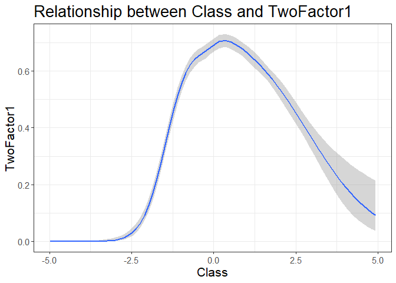

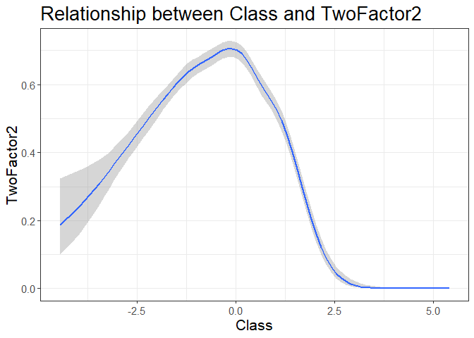

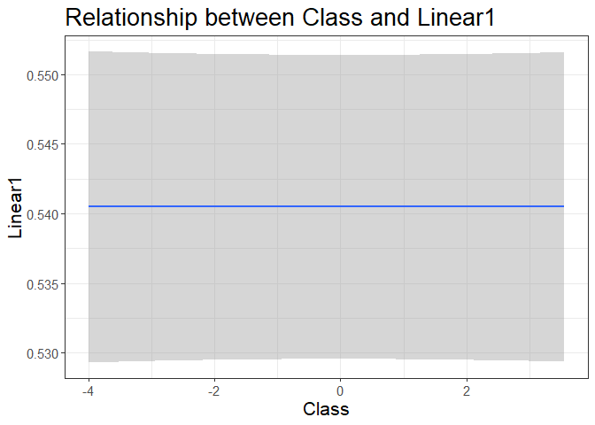

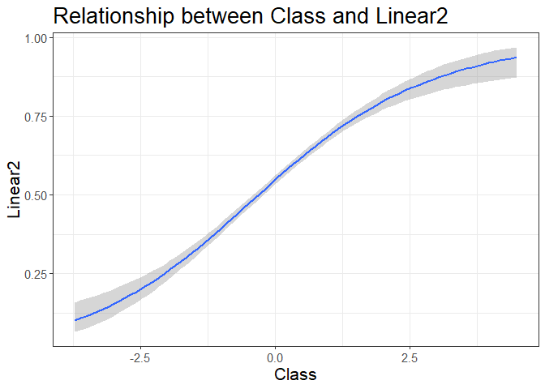

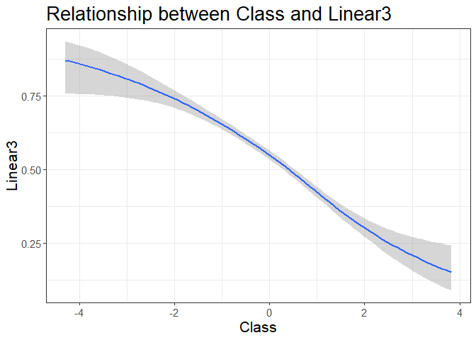

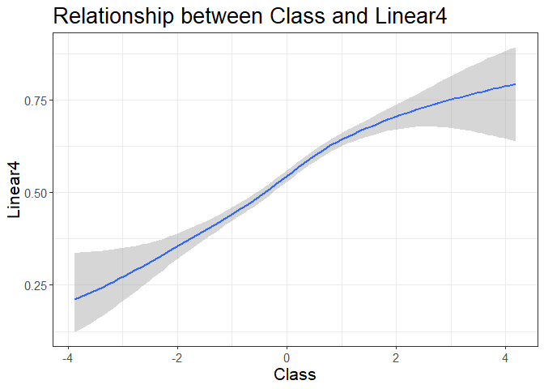

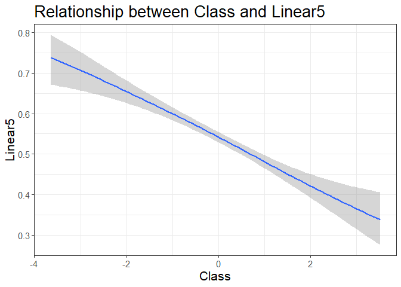

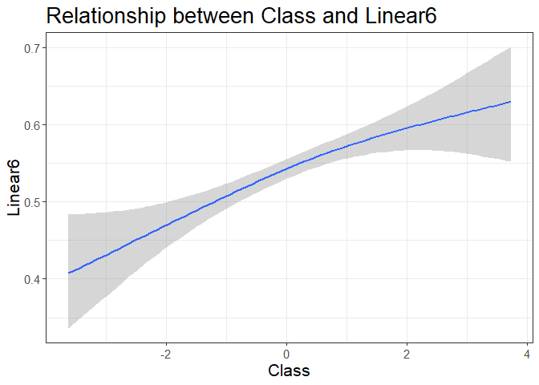

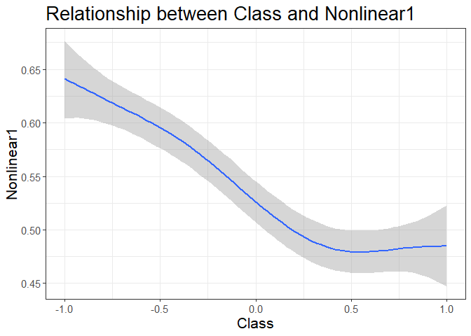

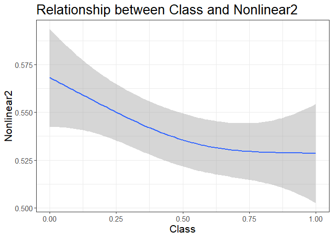

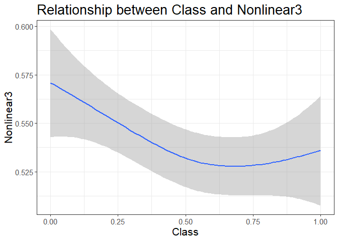

```r
synthetic.plot
```

```r
sapply(X = 1:length(synthetic.plot),FUN = function(X){ggsave(filename = paste("Plots/Synthetic/",names(training.data$Synthetic)[names(training.data$Synthetic)!="Class"][X],".pdf"),plot = synthetic.plot[[X]],width = 12,height = 7)})
```

```r
sapply(X = 1:length(banking.plot),FUN = function(X){
  ggsave(filename =  paste("Plots/Banking/",c("age","previous","euribor3m","cons_conf_idx","cons_price_idx","nr_employed", "emp_var_rate"   ,   "pdays")[X],".pdf"),
         plot = banking.plot[[X]],
         width = 12,
         height = 7)})
```

```r
sapply(X = 1:length(adult.plot),
       FUN = function(X){
         ggsave(filename = paste("Plots/Adult/",c("age","education_num","capital_gain","capital_loss","hours_per_week")[X],".pdf"),
                plot = adult.plot[[X]],
                width = 12,
                height = 7)})
```

The conclusions for each of the variables are discussed in the tables and figures below. The synthetic data is the only data-set containing truly linear variables. Additionally, we find that many of the variables being used in the real world data don’t have an obvious transformation that can be used to transform them into linear functions.

## Synthetic Data

[output not shown]

## Banking data-set

| Feature | Relationship |
| --- | --- |
| age | Nonlinear |
| cons_conf_idx | Nonlinear |
| cons_price_idx | Nonlinear |
| emp_var_rate | Nonlinear |
| euribor3m | Nonlinear |
| nr_employed | Nonlinear |
| pdays | Nonlinear |

## Adult data-set

| Feature | Relationship |
| --- | --- |
| age | Nonlinear |
| capital_gain | Nonlinear |
| capital_loss | Nonlinear |
| education_num | Near linear |
| hours_per_week | Nonlinear |

# Resampling procedure

The table above shows that the banking and adult data-sets have class imbalances present which may bias any models we fit. To fix this, I’ll generate synthetic instances of the minority classes using SMOTE. The synthetic data-set contains a very minor imbalance so no changes will be made to it before it’s split into training and testing data.

```r
# banking.smote <- RSBID::SMOTE_NC(data = training.data$Banking , outcome = "y" )
banking.smote <- readRDS(file = "banking_smote.RDS")
```

```r
# adult.smote <- RSBID::SMOTE_NC(data = training.data$Adult, outcome = "Income_class" )
# adult.smote <- saveRDS(adult.smote,file = "adult_smote.RDS")
adult.smote <- readRDS("adult_smote.RDS")
```

```r
dep.vars <- c("Class", "y", "Income_class")
summaries <- lapply(X = 1:length(training.data),FUN = function(x){sum.func(training.data[[x]], dep.vars[x] , model.name = names(training.data)[x])   })
summaries[[1]]$Banking <- summaries[[2]]$Banking
summaries[[1]]$Adult <- summaries[[3]]$Adult
kable(summaries[[1]],digits = 3)
```

| Measure | Synthetic | Banking | Adult |
| --- | --- | --- | --- |
| Observations | 8000.00 | 32950.000 | 26048.000 |
| Factors | 12.00 | 29.000 | 16.000 |
| Minority Class Percent | 0.46 | 0.114 | 0.239 |

# Implementation

## Building Decision Trees

```r
synthetic.tree.2 <- rpart(data = training.data$Synthetic,
                       formula = Class~Linear1+Linear2+Linear3+Linear4+Linear5+Linear6+Nonlinear1 +Nonlinear2 +Nonlinear3,
                        control = rpart.control(  maxdepth = 4 ))
banking.tree.3 <- rpart(data = banking.smote,
                       formula = y~.-V1, control = rpart.control(  maxdepth = 4)  )
adult.tree.3 <- rpart(data = adult.smote,
                       formula = Class~age+workclass+fnlwgt+education+education_num +marital_status+occupation+relationship+race+sex+capital_gain +  capital_loss + hours_per_week+ native_country,
                        control = rpart.control(  maxdepth = 4))
```

```r
source("build_logistic_w_tree.r")
synth.models <- list(synthetic.tree.2)
banking.models <- list(banking.tree.3)
adult.models <- list(adult.tree.3)

synth.train.preds <- lapply(X = synth.models,FUN = function(x){   tree.to.feature(tree.model = x,dt = training.data$Synthetic)  }) %>% data.frame
banking.train.preds <-lapply(X = banking.models,FUN = function(x){   tree.to.feature(tree.model = x,dt = training.data$Banking)  }) %>% data.frame
adult.train.preds <-lapply(X = adult.models,FUN = function(x){   tree.to.feature(tree.model = x,dt = training.data$Adult)  }) %>% data.frame

names(synth.train.preds) <- c("three.nodes")
names(banking.train.preds) <- c("four.nodes")
names(adult.train.preds) <- c("four.nodes")

training.data$Synthetic <- cbind( training.data$Synthetic,synth.train.preds )
training.data$Banking <- cbind(training.data$Banking ,banking.train.preds )
training.data$Adult <- cbind(training.data$Adult ,adult.train.preds )


synth.model.three.deep<- glm(formula = Class~Linear1+Linear2+Linear3+Linear4+Linear5+Linear6+Nonlinear1 +Nonlinear2 +Nonlinear3 + three.nodes,family = "binomial",data = training.data$Synthetic)

banking.mode.four.deep <- glm(formula = y~.-V1 ,family = "binomial",data = training.data$Banking)

adult.mode.four.deep <- glm(formula = Class~age+workclass+fnlwgt+education+education_num +marital_status+occupation+relationship+race+sex+capital_gain +  capital_loss + hours_per_week+ native_country + four.nodes,
                           family = "binomial",
                           data = training.data$Adult)
```

```r
# Create GAM models and the GLM models:
synth.gam <- gam(data = training.data$Synthetic,formula = Class~s(Linear1)+s(Linear2)+s(Linear3)+s(Linear4)+s(Linear5)+s(Linear6)+s(Nonlinear1) +s(Nonlinear2) +s(Nonlinear3),family = binomial)

banking.gam <- gam(formula = y~s(age)+s(previous)+s(euribor3m)+s(cons_conf_idx)+s(cons_price_idx)+s(nr_employed)+s(emp_var_rate)+s(pdays)+`job_blue-collar`+
                     job_management+`job_other 1`+`job_other 2`+job_services+job_technician+marital_married+marital_single+ education_high.school+education_professional.course+education_university.degree+education_unknown+default_unknown+housing_unknown+
                     housing_yes+loan_unknown+loan_yes+poutcome_nonexistent+poutcome_success,family = "binomial",data = training.data$Banking)

adult.gam <- gam(formula = Class~s(age)+(workclass)+s(fnlwgt)+(education)+s(education_num) +(marital_status)+(occupation)+(relationship)+(race)+(sex)+s(capital_gain) +  s(capital_loss) + s(hours_per_week)+ (native_country),
                           family = "binomial",
                           data = training.data$Adult)


# Create GLM Models

synth.model.glm<- glm(formula = Class~Linear1+Linear2+Linear3+Linear4+Linear5+Linear6+Nonlinear1 +Nonlinear2 +Nonlinear3 ,family = "binomial",data = training.data$Synthetic)

banking.mode.glm <- glm(formula = y~.-V1-four.nodes ,family = "binomial",data = training.data$Banking)

adult.mode.glm <- glm(formula = Class~age+workclass+fnlwgt+education+education_num +marital_status+occupation+relationship+race+sex+capital_gain +  capital_loss + hours_per_week+ native_country ,
                           family = "binomial",
                           data = training.data$Adult)
broom::tidy(synth.model.three.deep) %>% DT::datatable()
```

|  | term | estimate | std.error | statistic | p.value |
| --- | --- | --- | --- | --- | --- |
| 1 | (Intercept) | 0.297761065977192 | 0.109021915115428 | 2.73120377368104 | 0.00631034410822247 |
| 2 | Linear1 | 0.00689386103093722 | 0.025037614553554 | 0.275340169335687 | 0.78305490597655 |
| 3 | Linear2 | 0.658784712548328 | 0.042979743950569 | 15.3277951889615 | 4.98625948255233e-53 |
| 4 | Linear3 | -0.504334157907246 | 0.0399090915924918 | -12.6370743553113 | 1.31869970493431e-36 |
| 5 | Linear4 | 0.422832531218965 | 0.0313200335731419 | 13.5003856311815 | 1.55559756355255e-41 |
| 6 | Linear5 | -0.284503601918428 | 0.0257465747199637 | -11.0501534675145 | 2.18840455241492e-28 |
| 7 | Linear6 | 0.160566391337379 | 0.0252301878786496 | 6.36405848857168 | 1.96491260084085e-10 |
| 8 | Nonlinear1 | -0.461592817955952 | 0.0440080342134156 | -10.4888306466377 | 9.72241631669371e-26 |
| 9 | Nonlinear2 | -0.270356228428688 | 0.087018367652842 | -3.10688692193432 | 0.0018906870478865 |
| 10 | Nonlinear3 | -0.193874842744758 | 0.0870404831243791 | -2.22741000262733 | 0.0259198845249002 |

[output cut: 4 more lines]

```r
broom::tidy(banking.mode.four.deep) %>% DT::datatable()
```

|  | term | estimate | std.error | statistic | p.value |
| --- | --- | --- | --- | --- | --- |
| 1 | (Intercept) | -3.22178919122045 | 0.162333287779488 | -19.8467562339827 | 1.17548615571591e-87 |
| 2 | age | 0.0342073604931219 | 0.0207370736474612 | 1.64957510759045 | 0.099029869714935 |
| 3 | previous | -0.0147337378832165 | 0.0301803001603361 | -0.488190568183281 | 0.625414864638657 |
| 4 | euribor3m | 0.424749002259907 | 0.251117688758935 | 1.69143402186873 | 0.0907539390340015 |
| 5 | cons_conf_idx | -0.289747407291243 | 0.0415113646731925 | -6.97995379271061 | 2.95277163617643e-12 |
| 6 | cons_price_idx | -0.23639662287233 | 0.066190720330673 | -3.57144659691493 | 0.000355014942060594 |
| 7 | nr_employed | -0.581439354780052 | 0.112936953361564 | -5.14835346158658 | 2.62782960244711e-07 |
| 8 | emp_var_rate | 0.181882478375099 | 0.115212238825095 | 1.57867324018602 | 0.114411025811565 |
| 9 | pdays | -0.195632806365659 | 0.0413894328439379 | -4.72663655729006 | 2.28269299123186e-06 |
| 10 | `job_blue-collar`1 | -0.115260070507231 | 0.0751857714686801 | -1.5330037619584 | 0.125274928000258 |

[output cut: 22 more lines]

```r
broom::tidy(adult.mode.four.deep) %>% DT::datatable()
```

|  | term | estimate | std.error | statistic | p.value |
| --- | --- | --- | --- | --- | --- |
| 1 | (Intercept) | -8.9624517223144 | 0.51963963230861 | -17.2474368101925 | 1.16974893335648e-66 |
| 2 | age | 0.0255857288356856 | 0.00186777816191043 | 13.6984837693549 | 1.03666486188176e-42 |
| 3 | workclassFederal-gov | 1.12873919772038 | 0.175146182064721 | 6.44455496782272 | 1.15940109871211e-10 |
| 4 | workclassLocal-gov | 0.397845194422138 | 0.160701206713225 | 2.47568268191105 | 0.0132981710282707 |
| 5 | workclassNever-worked | -11.5279441118109 | 480.587265765084 | -0.0239872026019221 | 0.980862816615551 |
| 6 | workclassPrivate | 0.612243885805989 | 0.143768242736452 | 4.25854746606536 | 2.05759532745385e-05 |
| 7 | workclassSelf-emp-inc | 0.817549648909977 | 0.171672841214265 | 4.76225384939945 | 1.91442646017884e-06 |
| 8 | workclassSelf-emp-not-inc | 0.150530107128343 | 0.156702618915474 | 0.960610027899659 | 0.336748284697048 |
| 9 | workclassState-gov | 0.247126558767329 | 0.17307873905458 | 1.42782735832965 | 0.153341556193112 |
| 10 | workclassWithout-pay | -13.2799534643899 | 355.710795038836 | -0.0373335688700143 | 0.970219040053581 |

[output cut: 96 more lines]

```r
broom::tidy(synth.gam) %>% DT::datatable()
```

|  | term | df | sumsq | meansq | statistic | p.value |
| --- | --- | --- | --- | --- | --- | --- |
| 1 | s(Linear1) | 1 | 3.11062696860233e-05 | 3.11062696860233e-05 | 3.10227747826503e-05 | 0.995556097714267 |
| 2 | s(Linear2) | 1 | 406.442161377585 | 406.442161377585 | 405.351196458503 | 5.67436729657494e-88 |
| 3 | s(Linear3) | 1 | 335.000697087588 | 335.000697087588 | 334.101494093608 | 3.79396925681292e-73 |
| 4 | s(Linear4) | 1 | 278.06355274394 | 278.06355274394 | 277.31717943392 | 3.10822301494028e-61 |
| 5 | s(Linear5) | 1 | 115.536020277968 | 115.536020277968 | 115.225900519264 | 1.06879936090063e-26 |
| 6 | s(Linear6) | 1 | 36.3950773555895 | 36.3950773555895 | 36.2973863274549 | 1.76919552783575e-09 |
| 7 | s(Nonlinear1) | 1 | 110.089605696533 | 110.089605696533 | 109.794105108299 | 1.59266114866619e-25 |
| 8 | s(Nonlinear2) | 1 | 9.42204313940923 | 9.42204313940923 | 9.39675265651167 | 0.00218098068129342 |
| 9 | s(Nonlinear3) | 1 | 5.00517816890148 | 5.00517816890148 | 4.99174335746972 | 0.0254961813081019 |
| 10 | Residuals | 7962.99945678167 | 7984.43112673581 | 1.00269140668293 |  |  |

```r
broom::tidy(adult.gam) %>% DT::datatable()
```

|  | term | df | sumsq | meansq | statistic | p.value |
| --- | --- | --- | --- | --- | --- | --- |
| 1 | s(age) | 1 | 145.250533670595 | 145.250533670595 | 155.659867619032 | 1.27156130277139e-35 |
| 2 | workclass | 8 | 86.9084968884768 | 10.8635621110596 | 11.6420958831975 | 1.15280608989525e-16 |
| 3 | s(fnlwgt) | 1 | 1.02900809037679 | 1.02900809037679 | 1.10275163250151 | 0.293672814524982 |
| 4 | education | 15 | 829.096207998678 | 55.2730805332452 | 59.2342085173546 | 1.3907791131409e-176 |
| 5 | marital_status | 6 | 1828.04113754222 | 304.673522923704 | 326.507855405759 | 0 |
| 6 | occupation | 13 | 322.894104595406 | 24.8380080458004 | 26.6180161038022 | 1.54779078161699e-65 |
| 7 | relationship | 5 | 73.9135843870647 | 14.7827168774129 | 15.8421156469291 | 1.29798334462083e-15 |
| 8 | race | 4 | 20.7163737172484 | 5.17909342931211 | 5.55025153588491 | 0.000183500730943164 |
| 9 | sex | 1 | 81.8153486235653 | 81.8153486235653 | 87.678619927352 | 8.30516156279267e-21 |
| 10 | s(capital_gain) | 1 | 363.883448625704 | 363.883448625704 | 389.961041866387 | 3.63079591655509e-86 |

[output cut: 4 more lines]

```r
broom::tidy(banking.gam) %>% DT::datatable()
```

|  | term | df | sumsq | meansq | statistic | p.value |
| --- | --- | --- | --- | --- | --- | --- |
| 1 | s(age) | 1 | 29.0958462207252 | 29.0958462207252 | 29.501019260515 | 5.62827997297091e-08 |
| 2 | s(previous) | 1 | 378.771831453404 | 378.771831453404 | 384.046403403382 | 5.00636965678283e-85 |
| 3 | s(euribor3m) | 1 | 2522.44030336799 | 2522.44030336799 | 2557.56644466151 | 0 |
| 4 | s(cons_conf_idx) | 1 | 275.607870324146 | 275.607870324146 | 279.445836670342 | 1.79661505767192e-62 |
| 5 | s(cons_price_idx) | 1 | 314.485887173581 | 314.485887173581 | 318.865247784387 | 5.54069203398049e-71 |
| 6 | s(nr_employed) | 1 | 8.38750713318155 | 8.38750713318155 | 8.50430702742175 | 0.00354546054761253 |
| 7 | s(emp_var_rate) | 1 | 1044.4964651151 | 1044.4964651151 | 1059.04155875527 | 1.12680279200059e-228 |
| 8 | s(pdays) | 1 | 391.147480349542 | 391.147480349542 | 396.594388901955 | 9.99646082141579e-88 |
| 9 | `job_blue-collar` | 1 | 9.46016908286543 | 9.46016908286543 | 9.59190628807172 | 0.00195601323364025 |
| 10 | job_management | 1 | 1.34103503148355 | 1.34103503148355 | 1.35970956103835 | 0.243596276675671 |

[output cut: 17 more lines]

```r
broom::tidy(synth.model.glm) %>% DT::datatable()
```

|  | term | estimate | std.error | statistic | p.value |
| --- | --- | --- | --- | --- | --- |
| 1 | (Intercept) | 0.445292620240241 | 0.0664907344055976 | 6.69706274447096 | 2.12650333948807e-11 |
| 2 | Linear1 | 0.00768853978419163 | 0.0250110710993795 | 0.307405458712337 | 0.758534773765982 |
| 3 | Linear2 | 0.698678693830438 | 0.027270889468162 | 25.6199452036988 | 9.14641600451685e-145 |
| 4 | Linear3 | -0.565224583215226 | 0.0266048354095096 | -21.2451824833764 | 3.65280370079634e-100 |
| 5 | Linear4 | 0.462361265620378 | 0.0265644861263675 | 17.4052403431002 | 7.52893644983934e-68 |
| 6 | Linear5 | -0.284924249260117 | 0.0257329846063415 | -11.0723358995793 | 1.70887208233336e-28 |
| 7 | Linear6 | 0.159196984864185 | 0.0251970440584281 | 6.31808177558574 | 2.64829876087058e-10 |
| 8 | Nonlinear1 | -0.460752187686397 | 0.0439500543521801 | -10.4835407936996 | 1.02820559525559e-25 |
| 9 | Nonlinear2 | -0.270051356758536 | 0.0869526268226274 | -3.10572971313917 | 0.00189810126672783 |
| 10 | Nonlinear3 | -0.197371000968077 | 0.086884364016398 | -2.27165155897126 | 0.0231075641394928 |

```r
broom::tidy(banking.mode.glm) %>% DT::datatable()
```

|  | term | estimate | std.error | statistic | p.value |
| --- | --- | --- | --- | --- | --- |
| 1 | (Intercept) | -2.96089192665953 | 0.123154540930029 | -24.0420848821302 | 1.01011508251759e-127 |
| 2 | age | 0.0481395214290446 | 0.0205539719766592 | 2.34210309733375 | 0.0191754171886321 |
| 3 | previous | 0.010822722182467 | 0.0303137113576737 | 0.357023990060765 | 0.721073846230421 |
| 4 | euribor3m | 0.0552915395186134 | 0.143055321268672 | 0.386504598558558 | 0.699122997555689 |
| 5 | cons_conf_idx | 0.0837932112560128 | 0.0266175142207241 | 3.14804795673866 | 0.00164364725361997 |
| 6 | cons_price_idx | 0.324144199968528 | 0.0541336347870537 | 5.98785212268895 | 2.12630247748293e-09 |
| 7 | nr_employed | -0.327855111508887 | 0.100775556610007 | -3.25331977850202 | 0.00114065054489958 |
| 8 | emp_var_rate | -0.790032578012353 | 0.102100168181479 | -7.73781857644055 | 1.01137023153727e-14 |
| 9 | pdays | -0.201080198205292 | 0.0412396009393056 | -4.87590067860336 | 1.08313099777066e-06 |
| 10 | `job_blue-collar`1 | -0.190395760098685 | 0.0741385437349793 | -2.56810763345024 | 0.0102255400275757 |

[output cut: 18 more lines]

```r
broom::tidy(adult.mode.glm) %>% DT::datatable()
```

|  | term | estimate | std.error | statistic | p.value |
| --- | --- | --- | --- | --- | --- |
| 1 | (Intercept) | -8.83452875674285 | 0.508599479867977 | -17.3703063145801 | 1.38484705732643e-67 |
| 2 | age | 0.0255723223681898 | 0.0018535198061239 | 13.7966275211631 | 2.67056937310267e-43 |
| 3 | workclassFederal-gov | 1.1263547807123 | 0.173111586814251 | 6.50652449925772 | 7.69093647488199e-11 |
| 4 | workclassLocal-gov | 0.403988688917861 | 0.158559666126733 | 2.54786541108734 | 0.0108384277001161 |
| 5 | workclassNever-worked | -11.5659185358776 | 483.68549601693 | -0.0239120639984473 | 0.980922751355872 |
| 6 | workclassPrivate | 0.617103371755685 | 0.141713209840123 | 4.35459314238868 | 1.33314288276627e-05 |
| 7 | workclassSelf-emp-inc | 0.823294335839411 | 0.169897743650665 | 4.84582265867066 | 1.26088108834894e-06 |
| 8 | workclassSelf-emp-not-inc | 0.170794976343925 | 0.154733508409845 | 1.10380083861045 | 0.269679541007771 |
| 9 | workclassState-gov | 0.255092363890059 | 0.171284452511445 | 1.48929082674923 | 0.136410802257376 |
| 10 | workclassWithout-pay | -13.2650012332244 | 350.641873757498 | -0.0378306249937463 | 0.969822726628846 |

[output cut: 91 more lines]

## Out-of-Sample Testing

```r
synth.test.preds <- lapply(X = synth.models,FUN = function(x){
     tree.to.feature(tree.model = x,dt = test.data$Synthetic)  }) %>% data.frame
banking.test.preds <-lapply(X = banking.models,FUN = function(x){
      tree.to.feature(tree.model = x,dt = test.data$Banking)  }) %>% data.frame
adult.test.preds <- lapply(X = adult.models,FUN = function(x){
      tree.to.feature(tree.model = x,dt = test.data$Adult)  }) %>% data.frame

names(synth.test.preds) <- c( "three.nodes")
names(banking.test.preds) <- c( "four.nodes")
names(adult.test.preds) <- c( "four.nodes")

test.data$Synthetic <- cbind( test.data$Synthetic,synth.test.preds )
test.data$Banking <- cbind(test.data$Banking ,banking.test.preds )
test.data$Adult <- cbind(test.data$Adult ,adult.test.preds )
```

```r
training.for.mmdata <- data.frame(predict(banking.mode.glm,newdata = training.data$Banking, type = "response" ),
                                 predict(banking.mode.four.deep, newdata = training.data$Banking,type = "response" ),
                                  predict(banking.gam,newdata = training.data$Banking, type = "response" )  )
training.mdat <- mmdata(scores = training.for.mmdata,labels = training.data$Banking$y,
                       modnames = c("Logistic Regression", "Tree w/ GLM", "GAM"))
```

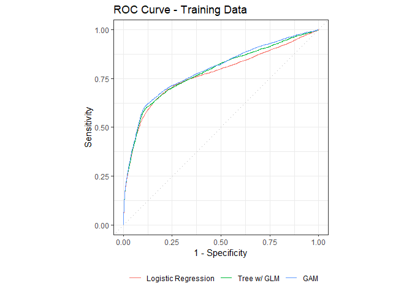

```r
autoplot(evalmod(training.mdat),curvetype = c("ROC"))+theme(legend.position = "bottom") +ggtitle("ROC Curve - Training Data")
```

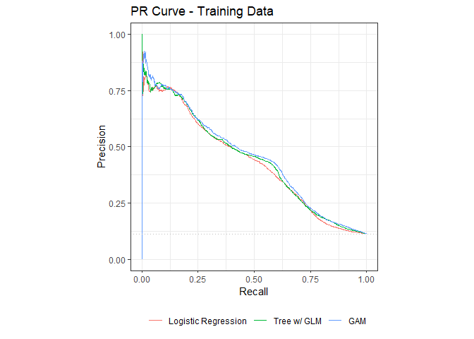

```r
autoplot(evalmod(training.mdat),curvetype = c("PR"))+theme(legend.position = "bottom") +ggtitle("PR Curve - Training Data")
```

```r
testing.for.mmdata <- data.frame(predict(synth.model.glm,newdata = test.data$Synthetic, type = "response" ),
                                 predict(synth.model.three.deep, newdata = test.data$Synthetic,type = "response" ),
                                  predict(synth.gam,newdata = test.data$Synthetic, type = "response" )  )
testing_mdat <- mmdata(scores = testing.for.mmdata,labels = test.data$Synthetic$Class,
                       modnames = c("Logistic Regression", "Tree w/ GLM", "GAM"))
```

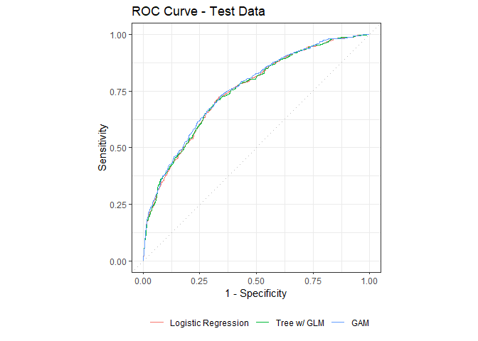

```r
autoplot(evalmod(testing_mdat),curvetype = c("ROC"))+theme(legend.position = "bottom") +ggtitle("ROC Curve - Test Data")
```

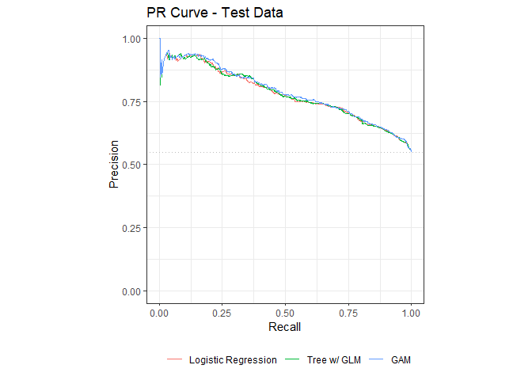

```r
autoplot(evalmod(testing_mdat),curvetype = c("PR"))+theme(legend.position = "bottom") +ggtitle("PR Curve - Test Data")
```

```r
testing.for.mmdata <- data.frame(predict(adult.mode.glm,newdata = test.data$Adult, type = "response" ),
                                 predict(adult.mode.four.deep, newdata = test.data$Adult,type = "response" ),
                                  predict(adult.gam,newdata = test.data$Adult, type = "response" )  )
testing_mdat <- mmdata(scores = testing.for.mmdata,labels = test.data$Adult$Class,
                       modnames = c("Logistic Regression", "Tree w/ GLM", "GAM"))
```

[figure not shown]

```r
autoplot(evalmod(testing_mdat),curvetype = c("ROC"))+theme(legend.position = "bottom") +ggtitle("ROC Curve - Training Data")
```

[figure not shown]

```r
autoplot(evalmod(testing_mdat),curvetype = c("PR"))+theme(legend.position = "bottom") +ggtitle("PR Curve - Training Data")
```

```r
format.auc.results <- function(x){
  return( data.table(   ROC.AUC = auc(x)[4][,1][1] , PR.AUC = auc(x)[4][,1][2]  )     )}

train.model.synthetic.glm<- evalmod(scores= predict(synth.model.glm , type = "response" ), labels  =    synth.model.glm$data$Class    )
train.model.synthetic.mixed<- evalmod(scores= predict(synth.model.three.deep , type = "response")  , labels  =  synth.model.three.deep$data$Class      )
train.model.synthetic.gam<- evalmod(scores= predict(synth.gam, type = "response" ), labels  =    synth.model.three.deep$data$Class    )

train.model.banking.glm<- evalmod(scores= predict(banking.mode.glm, type = "response" ), labels  =   banking.mode.four.deep$data$y     )
train.model.banking.mixed<- evalmod(scores= predict(banking.mode.four.deep , type = "response"), labels  =    banking.mode.four.deep$data$y    )
train.model.banking.gam<- evalmod(scores= predict(banking.gam , type = "response"), labels  =    banking.mode.four.deep$data$y    )

train.model.adult.glm<- evalmod(scores= predict(adult.mode.glm, type = "response" ), labels  =   adult.mode.four.deep$data$Class     )
train.model.adult.mixed<- evalmod(scores= predict(adult.mode.four.deep, type = "response" ), labels  =   adult.mode.four.deep$data$Class     )
train.model.adult.gam<- evalmod(scores= predict(adult.gam, type = "response" ), labels  = adult.mode.four.deep$data$Class       )

format.auc.results <- function(x){
  return( data.table(   ROC.AUC = auc(x)[4][,1][1] , PR.AUC = auc(x)[4][,1][2]  )     )}
training.results.synthetic <- lapply(X = list(train.model.synthetic.glm,train.model.synthetic.mixed,train.model.synthetic.gam),format.auc.results) %>% rbindlist
training.results.banking <- lapply(X = list(train.model.banking.glm,train.model.banking.mixed,train.model.banking.gam),format.auc.results) %>% rbindlist
training.results.adult <- lapply(X = list(train.model.adult.glm,train.model.adult.mixed,train.model.adult.gam),format.auc.results) %>% rbindlist
training.results.synthetic$Model <- c("Logistic","GLM + Tree","GAM")
training.results.banking$Model <- c("Logistic","GLM + Tree","GAM")
training.results.adult$Model <- c("Logistic","GLM + Tree","GAM")
training.results.synthetic$Data <- "Synthetic"
training.results.banking$Data <- "Banking"
training.results.adult$Data <- "Adult"
training.list <-rbindlist( list(training.results.synthetic,training.results.banking,training.results.adult))
training.list$Label <- "In-Sample"

test.model.synthetic.glm<- evalmod(scores= predict(synth.model.glm,newdata = test.data$Synthetic, type = "response" ), labels  =    test.data$Synthetic$Class    )
test.model.synthetic.mixed<- evalmod(scores= predict(synth.model.three.deep , type = "response")  , labels  =  synth.model.three.deep$data$Class      )
test.model.synthetic.gam<- evalmod(scores= predict(synth.gam, type = "response" ), labels  =    synth.model.three.deep$data$Class    )
test.model.banking.glm<- evalmod(scores= predict(banking.mode.glm, type = "response" ), labels  =   banking.mode.four.deep$data$y     )
test.model.banking.mixed<- evalmod(scores= predict(banking.mode.four.deep , type = "response"), labels  =    banking.mode.four.deep$data$y    )
test.model.banking.gam<- evalmod(scores= predict(banking.gam , type = "response"), labels  =    banking.mode.four.deep$data$y    )
test.model.adult.glm<- evalmod(scores= predict(adult.mode.glm, type = "response" ), labels  =   adult.mode.four.deep$data$Class     )
test.model.adult.mixed<- evalmod(scores= predict(adult.mode.four.deep, type = "response" ), labels  =   adult.mode.four.deep$data$Class     )
test.model.adult.gam<- evalmod(scores= predict(adult.gam, type = "response" ), labels  = adult.mode.four.deep$data$Class       )
testing.results.synthetic <- lapply(X = list(test.model.synthetic.glm,test.model.synthetic.mixed,test.model.synthetic.gam),format.auc.results) %>% rbindlist
testing.results.banking <- lapply(X = list(test.model.banking.glm,test.model.banking.mixed,test.model.banking.gam),format.auc.results) %>% rbindlist
testing.results.adult <- lapply(X = list(test.model.adult.glm,test.model.adult.mixed,test.model.adult.gam),format.auc.results) %>% rbindlist
testing.results.synthetic$Model <- c("Logistic","GLM + Tree","GAM")
testing.results.banking$Model <- c("Logistic","GLM + Tree","GAM")
testing.results.adult$Model <- c("Logistic","GLM + Tree","GAM")
testing.results.synthetic$Data <- "Synthetic"
testing.results.banking$Data <- "Banking"
testing.results.adult$Data <- "Adult"
testing.list <- rbindlist(list(testing.results.synthetic,testing.results.banking,testing.results.adult))
testing.list$Label <- "Out-of-Sample"
```

```r
results.list <- rbindlist(list(training.list,testing.list))
results.list <- results.list[,c(5,4,3,1,2)]
results.list <- melt(data = results.list,id.vars = c("Data","Model","Label"))
results.list <-dcast(data = results.list,formula = Data + Model ~ Label + variable,fun.aggregate = function(x){return(sum(x,na.rm=F))},value.var = "value")
reactable(data = results.list,groupBy = c("Data"),
            columns = list( `In-Sample_ROC.AUC` = colDef(name = "ROC.AUC",format =colFormat(digits = 3) ),
                            `In-Sample_PR.AUC` = colDef(name = "PR.AUC",format =colFormat(digits = 3)),
                            `Out-of-Sample_ROC.AUC` = colDef(name = "ROC.AUC",format =colFormat(digits = 3)),
                            `Out-of-Sample_PR.AUC` = colDef(name = "PR.AUC",format =colFormat(digits = 3)) ),
    columnGroups = list( colGroup( name = "In-Sample", columns = c("In-Sample_ROC.AUC","In-Sample_PR.AUC")    ),
                               colGroup( name = "Out-of-Sample", columns = c("Out-of-Sample_ROC.AUC","Out-of-Sample_PR.AUC"  ) )),defaultExpanded = T, defaultSortOrder = "desc")
```

[output not shown]